# ggplot2_CH3

## 3.4 Annotations

1. Annotations add metadata to your plot. But metadata is just data, so you can use:
1. `geom_text()`: add text descriptions or to label points. Labelling outliers and other important points is very useful.
2. `geom_rect()`: highlight interesting rectangular regions of the plot.
1. `geom_rect()` has aesthetics `xmin`, `xmax`, `ymin`, `ymax`.
3. `geom_line()`, `geom_path()`, `geom_segment()`: to add lines.
1. All these geoms have an `arrow` parameter, which allows you to place an arrowhead on the line. Create arrowheads with `arrow()`, which has arguments `angle`, `length`, `ends`, `type`.
4. `geom_vline()`, `geom_hline()`, `geom_abline()`: allow you to add reference lines (somtimes called rules), that span the full range of the plot.
2. Either put annotations in the foreground (using `alpha` if needed so you can still see the data), or in the background.
1. The default is in the background.

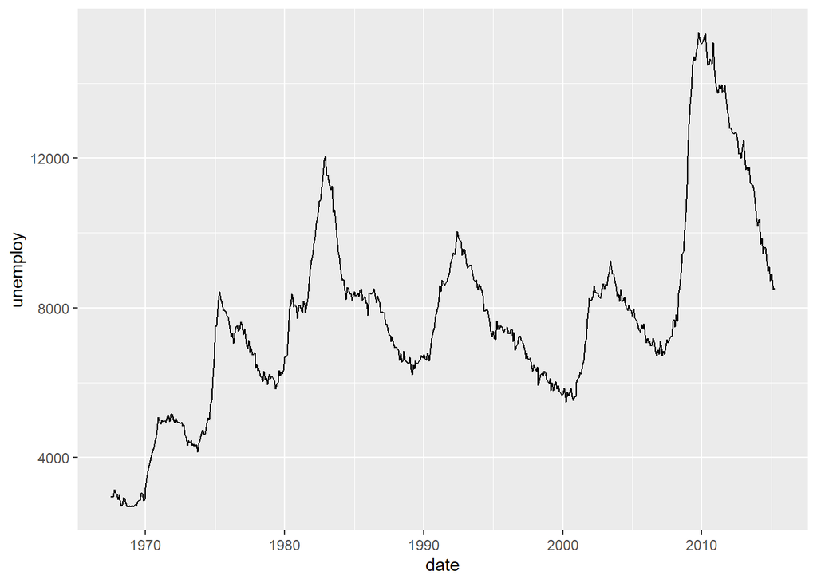

```r
# Time series of unemploytment
ggplot(economics, aes(date, unemploy))+
  geom_line()
```

2. The use `-Inf` and `Inf` as positions. These refer to the top and bottom (or left and right) limits of the plot.

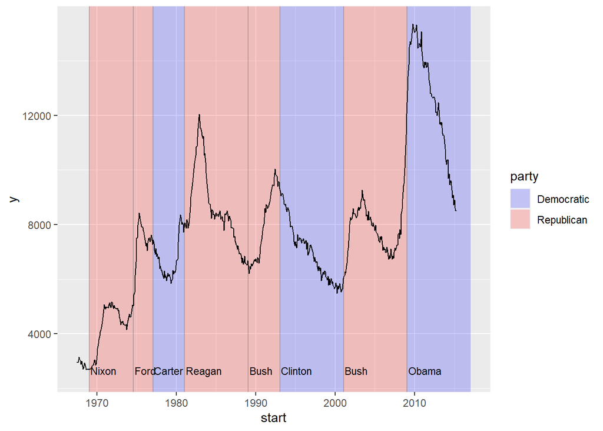

```r
# Annotate the time series with which president was in power at the time

presidential=subset(presidential, start>economics$date[1])

ggplot(economics)+
  geom_rect(
    aes(xmin=start, xmax=end, fill=party),
    ymin=-Inf, ymax=Inf, alpha=0.2, data=presidential
  )+
  geom_vline(
    aes(
      xintercept=as.numeric(start)
    ),
    data=presidential,
    color="grey50", alpha=0.5
  )+geom_text(
    aes(x=start, y=2500, label=name),
    data=presidential,
    size=3, vjust=0, hjust=0, nudge_x=50
  )+geom_line(aes(date, unemploy))+
  scale_fill_manual(values=c("blue", "red"))
```

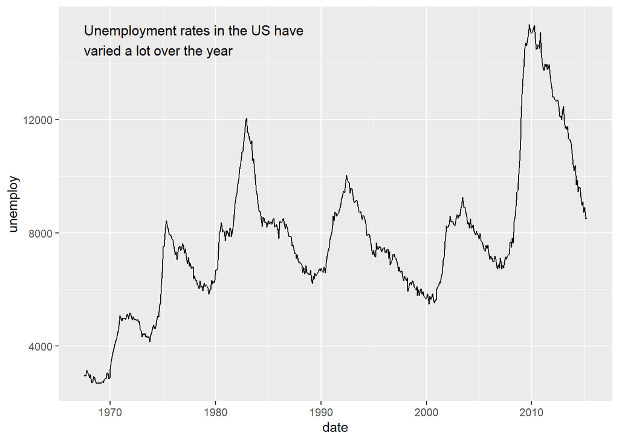

```r
# Add a single annotation to a plot: have to create a one row data frame

yrng=range(economics$unemploy)
xrng=range(economics$date)

caption=paste(strwrap("Unemployment rates in the US have varied a lot over the year", 40), collapse="\n")


ggplot(economics, aes(date, unemploy))+
  geom_line()+
  geom_text(
    aes(x,y,label=caption),
    data=data.frame(x=xrng[1],y=yrng[2],caption=caption),
    hjust=0, vjust=1, size=4
  )
```

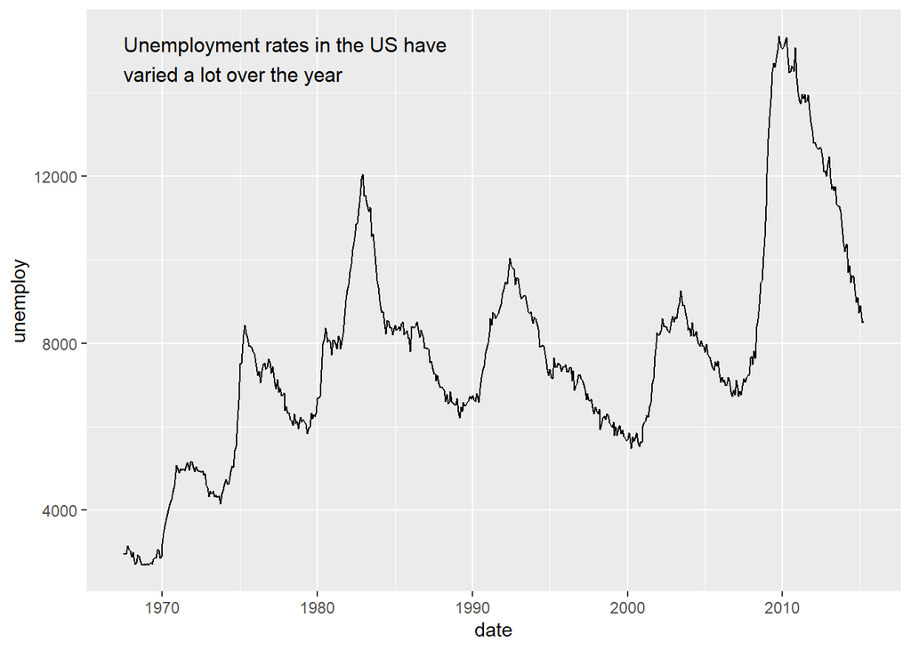

```r
# Easier to use the annotate() helper function which creates the data frame for you

ggplot(economics, aes(date, unemploy))+
  geom_line()+
  annotate("text", x=xrng[1], y=yrng[2], label=caption, hjust=0, vjust=1, size=4)
```

3. Annotations, particularly reference lines, are also useful when comparing groups across facets.

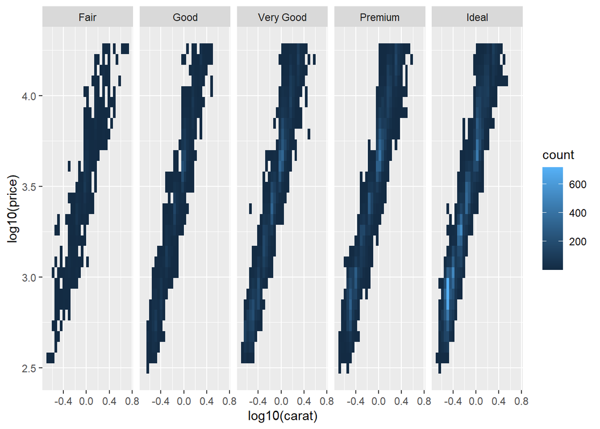

```r
# Without reference lines
ggplot(diamonds, aes(log10(carat), log10(price)))+
  geom_bin2d()+
  facet_wrap(~cut, nrow=1)
```

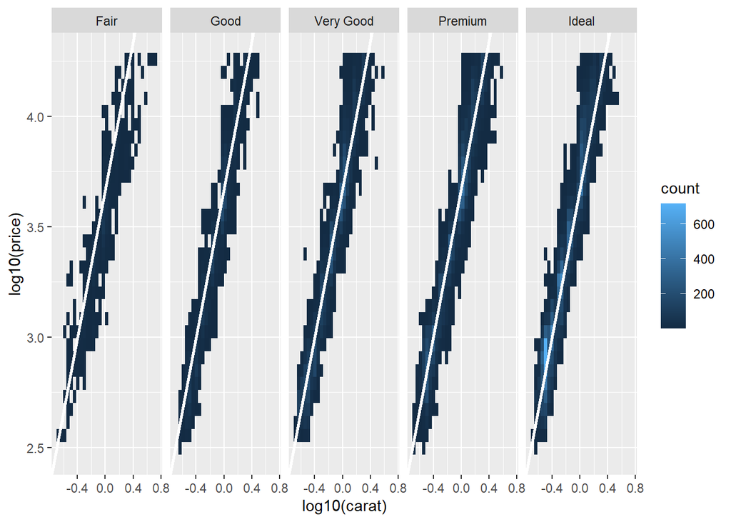

```r
# With reference lines

mod_coef=coef(lm(log10(price)~log10(carat), data=diamonds))

ggplot(diamonds, aes(log10(carat), log10(price)))+
  geom_bin2d()+
  geom_abline(intercept=mod_coef[1], slope=mod_coef[2], color="white", size=1)+
  facet_wrap(~cut, nrow=1)
```

## 3.5 Collective Geoms

1. Geoms can be roughly divided into two types:
1. **Individual Geom**: draws a distinct graphical object for EACH observation (row).
1. For exaple, the point geom draws one point per row.
2. **Collective Geom**: displays ultiple observations with one geometric object.
1. For example, this may be a result of a statistical summary, like a boxplot.
2. Or this may be fundamental to the display of the geom, like a polygon.
2. **Lines** and **Paths**: fall somewhere in between individual geom and collective geom:
1. Each line is composed of a set of straight segments, but each segment represents two points.
3. **Group** Aesthetic: control the assignment of observations to graphical elements.
1. By default, the `group` aesthetic is mapped to the interaction of all discrete variables in the plot.
1. This often partitions the data correctly.
2. If it does NOT partition the data correctly or when NO discrete variable is used in a plot, need to explicitly definthe grouping structure by mapping `group` to a variable that has a different value for each group.

### 3.5.1. Multiple Groups, One Aesthetic

1. Separate data into groups, but render them in the same way. That is, want to be able to distringuish individual subjects, but NOT identify them.
1. Commonly used in longitudinal studies with many subjects.
2. Plots are often called **Spaghetti Plots**.

[figure not shown]

```r
ggplot(Oxboys, aes(age, height, grou=Subject))+
  geom_point()+
  geom_line()
```

3. If a group is NOT defined by a single variable, but instead by a combination of multiple variables, use **interaction()** to combine them, e.g. `aes(group=interaction(school_id, student_id))`.